# Analyse de la présence du lynx par site occupancy

2026-06-29

## Import librairies

```r
#importation tidyverse

library(readr)
library(tidyr)
library(dplyr)
```

```r
library(ggplot2)
library(tibble)
library(stringr)
library(forcats)
library(lubridate)
#importation des autres librairies

library(emmeans)
library(glmmTMB)
library(bbmle)
library(blme)
library(lme4)
library(lmerTest)
library(MuMIn)
library(performance)
library(ggeffects)

library(ggsignif)

library(car)
library(unmarked)
library(AICcmodavg)
```

## Import des données

```r
Tidy_Site_Occupancy <- read_csv("Data/Tidy_Site_Occupancy.csv")
View(Tidy_Site_Occupancy)

Tidy_Effort_Capture <- read_csv("Data/Tidy_Effort_Capture.csv")
#View(Tidy_Effort_Capture)

Tidy_Ecart_Attractif <- read_csv("Data/Tidy_Ecart_Attractif.csv")
#View(Tidy_Ecart_Attractif)

Tidy_PE <- read_csv("Data/Tidy_PE.csv")
Tidy_PE$V1 <- as.factor(Tidy_PE$V1)
Tidy_PE$V2 <- as.factor(Tidy_PE$V2)
Tidy_PE$V3 <- as.factor(Tidy_PE$V3)
Tidy_PE$V4 <- as.factor(Tidy_PE$V4)
Tidy_PE$V5 <- as.factor(Tidy_PE$V5)
Tidy_PE$V6 <- as.factor(Tidy_PE$V6)
Tidy_PE$V7 <- as.factor(Tidy_PE$V7)
Tidy_PE$V8 <- as.factor(Tidy_PE$V8)
Tidy_PE$V9 <- as.factor(Tidy_PE$V9)
Tidy_PE$V10 <- as.factor(Tidy_PE$V10)
Tidy_PE$V11 <- as.factor(Tidy_PE$V11)
Tidy_PE$V12 <- as.factor(Tidy_PE$V12)
Tidy_PE$V13 <- as.factor(Tidy_PE$V13)
Tidy_PE$V14 <- as.factor(Tidy_PE$V14)
Tidy_PE$V15 <- as.factor(Tidy_PE$V15)
Tidy_PE$V16 <- as.factor(Tidy_PE$V16)
Tidy_PE$V17 <- as.factor(Tidy_PE$V17)
Tidy_PE$V18 <- as.factor(Tidy_PE$V18)
Tidy_PE$V19 <- as.factor(Tidy_PE$V19)
Tidy_PE$V20 <- as.factor(Tidy_PE$V20)
Tidy_PE$V21 <- as.factor(Tidy_PE$V21)
Tidy_PE$V22 <- as.factor(Tidy_PE$V22)
Tidy_PE$V23 <- as.factor(Tidy_PE$V23)
Tidy_PE$V24 <- as.factor(Tidy_PE$V24)
Tidy_PE$V25 <- as.factor(Tidy_PE$V25)
Tidy_PE$V26 <- as.factor(Tidy_PE$V26)
Tidy_PE$V27 <- as.factor(Tidy_PE$V27)
Tidy_PE$V28 <- as.factor(Tidy_PE$V28)
Tidy_PE$V29 <- as.factor(Tidy_PE$V29)
Tidy_PE$V30 <- as.factor(Tidy_PE$V30)
Tidy_PE$V31 <- as.factor(Tidy_PE$V31)
Tidy_PE$V32 <- as.factor(Tidy_PE$V32)
Tidy_PE$V33 <- as.factor(Tidy_PE$V33)
Tidy_PE$V34 <- as.factor(Tidy_PE$V34)

caracteristique_MS <- read_csv("Data/caracteristiques_MS.csv")
```

## Formatage des données

On rajoute à Tidy_Site_Occupancy les caractéristiques associées aux microsites.

```r
Tidy_Site_Occupancy <- Tidy_Site_Occupancy %>%
  mutate(odorant = NA,
         typepiege = NA,
         support = NA,
         hauteur_camera_cm = NA,
         typelieu = NA)

n = nrow(Tidy_Site_Occupancy)

for(i in 1:n){
  index = Tidy_Site_Occupancy$MS[i]
  Tidy_Site_Occupancy$odorant[i] = caracteristique_MS$odorant[caracteristique_MS$MS == index]
  Tidy_Site_Occupancy$support[i] = caracteristique_MS$support[caracteristique_MS$MS == index]
  Tidy_Site_Occupancy$typepiege[i] = caracteristique_MS$typepiege[caracteristique_MS$MS == index]
  Tidy_Site_Occupancy$typelieu[i] = caracteristique_MS$typelieu[caracteristique_MS$MS == index]
  Tidy_Site_Occupancy$hauteur_camera_cm[i] = caracteristique_MS$hauteur_camera_cm[caracteristique_MS$MS == index]

}
```

On convertit les data.frame en objets unmarkedFrameOccu pour qu’ils puissent être traités par les fonctions du package unmarked.

```r
y <- Tidy_Site_Occupancy[, 2:35]
siteCovs <- Tidy_Site_Occupancy[, c("support", "odorant", "typepiege", "typelieu", "hauteur_camera_cm")]
obsCovs <- list(effort_capture = Tidy_Effort_Capture[, 2:ncol(Tidy_Effort_Capture)],
                PE = Tidy_PE[, 2:ncol(Tidy_PE)],
                ecart_attractif = Tidy_Ecart_Attractif[, 2:ncol(Tidy_Ecart_Attractif)]
                )
data <- unmarkedFrameOccu(y = y, siteCovs = siteCovs, obsCovs = obsCovs)
```

## Création de différents modèles

```r
modele_naif <- occu(formula = ~ 1 ~ 1 , data = data)
summary(modele_naif)
```

```
##
## Call:
## occu(formula = ~1 ~ 1, data = data)
##
## Occupancy (logit-scale):
##  Estimate    SE    z P(>|z|)
##      2.41 0.748 3.22 0.00126
##
## Detection (logit-scale):
##  Estimate    SE     z  P(>|z|)
##     -1.51 0.097 -15.5 1.59e-54
##
## AIC: 701.5553
## Number of sites: 24
```

Création des autres modèles possibles en testant un à un les effets des différents paramètres étudiés :

```r
modele_effort_capture <- occu(formula = ~ scale(effort_capture) ~ 1 , data = data)
modele_PE <- occu(formula = ~ PE ~ 1 , data = data)
modele_ecart_attractif <- occu(formula = ~ ecart_attractif ~ 1 , data = data)
modele_support <- occu(formula = ~ support ~ 1 , data = data)
modele_odorant <- occu(formula = ~ odorant ~ 1 , data = data)
modele_typepiege <- occu(formula = ~ typepiege ~ 1 , data = data)
modele_typelieu <- occu(formula = ~ typelieu ~ 1 , data = data)
modele_hauteur_camera_cm <- occu(formula = ~ hauteur_camera_cm ~ 1 , data = data)
```

On créé une liste contenant ces modèles, par calculer toutes les AICs d’un seul coup :

```r
modlist1<-list(modele_naif = modele_naif,
               modele_effort_capture = modele_effort_capture,
               modele_PE = modele_PE,
               modele_ecart_attractif = modele_ecart_attractif,
               modele_support = modele_support,
               modele_odorant = modele_odorant,
               modele_typepiege = modele_typepiege,
               modele_typelieu = modele_typelieu,
               modele_hauteur_camera_cm = modele_hauteur_camera_cm)

aictab(modlist1)
```

```
##
## Model selection based on AICc:
##
##                          K   AICc Delta_AICc AICcWt Cum.Wt      LL
## modele_ecart_attractif   3 681.30       0.00   0.47   0.47 -337.05
## modele_typelieu          4 681.41       0.11   0.45   0.92 -335.65
## modele_odorant           5 684.88       3.58   0.08   1.00 -335.77
## modele_support           4 693.62      12.33   0.00   1.00 -341.76
## modele_PE                4 693.84      12.54   0.00   1.00 -341.87
## modele_hauteur_camera_cm 3 700.47      19.17   0.00   1.00 -346.64
## modele_naif              2 702.13      20.83   0.00   1.00 -348.78
## modele_typepiege         3 704.73      23.43   0.00   1.00 -348.76
## modele_effort_capture    3 704.75      23.45   0.00   1.00 -348.78
```

Le modèle ayant l’AICc la plus faible est : modele_ecart_attractif. Il y a une différence d’au moins 2 entre ce modèle et chacun des autres (sauf pour modele_typelieu).

On regarde maintenant un par un les modèles pour voir quels effets sont significatifs :

```r
summary(modele_effort_capture)
```

```
##
## Call:
## occu(formula = ~scale(effort_capture) ~ 1, data = data)
##
## Occupancy (logit-scale):
##  Estimate    SE    z P(>|z|)
##      2.41 0.748 3.22 0.00126
##
## Detection (logit-scale):
##                       Estimate    SE        z  P(>|z|)
## (Intercept)            -1.5065 0.101 -14.9318 2.05e-50
## scale(effort_capture)  -0.0106 0.187  -0.0565 9.55e-01
##
## AIC: 703.5521
## Number of sites: 24
```

```r
summary(modele_PE)
```

```
##
## Call:
## occu(formula = ~PE ~ 1, data = data)
##
## Occupancy (logit-scale):
##  Estimate    SE    z P(>|z|)
##      2.41 0.747 3.23 0.00125
##
## Detection (logit-scale):
##             Estimate    SE     z  P(>|z|)
## (Intercept)   -1.384 0.140 -9.88 5.17e-23
## PE2            0.252 0.228  1.11 2.69e-01
## PE3           -0.702 0.251 -2.80 5.09e-03
##
## AIC: 691.7374
## Number of sites: 24
```

```r
summary(modele_ecart_attractif)
```

```
##
## Call:
## occu(formula = ~ecart_attractif ~ 1, data = data)
##
## Occupancy (logit-scale):
##  Estimate    SE    z P(>|z|)
##      2.41 0.747 3.23 0.00126
##
## Detection (logit-scale):
##                 Estimate     SE      z  P(>|z|)
## (Intercept)       -2.119 0.1698 -12.47 1.04e-35
## ecart_attractif    0.099 0.0203   4.86 1.15e-06
##
## AIC: 680.0986
## Number of sites: 24
```

```r
summary(modele_support)
```

```
##
## Call:
## occu(formula = ~support ~ 1, data = data)
##
## Occupancy (logit-scale):
##  Estimate    SE    z P(>|z|)
##      2.43 0.764 3.19 0.00144
##
## Detection (logit-scale):
##               Estimate    SE     z  P(>|z|)
## (Intercept)     -1.439 0.170 -8.44 3.17e-17
## supportPiquet   -0.356 0.224 -1.59 1.12e-01
## supportRocher    0.639 0.275  2.32 2.04e-02
##
## AIC: 691.5196
## Number of sites: 24
```

```r
summary(modele_odorant)
```

```
##
## Call:
## occu(formula = ~odorant ~ 1, data = data)
##
## Occupancy (logit-scale):
##  Estimate    SE z P(>|z|)
##      2.54 0.845 3 0.00268
##
## Detection (logit-scale):
##                            Estimate    SE      z  P(>|z|)
## (Intercept)                 -0.9561 0.199 -4.806 1.54e-06
## odorantCastoreum_Urine      -0.9956 0.284 -3.501 4.64e-04
## odorantLavande_Sansodorant   0.0346 0.278  0.124 9.01e-01
## odorantLavande_Urine        -0.9948 0.287 -3.466 5.29e-04
##
## AIC: 681.543
## Number of sites: 24
```

```r
summary(modele_typepiege)
```

```
##
## Call:
## occu(formula = ~typepiege ~ 1, data = data)
##
## Occupancy (logit-scale):
##  Estimate    SE    z P(>|z|)
##      2.41 0.748 3.22 0.00126
##
## Detection (logit-scale):
##                 Estimate    SE       z  P(>|z|)
## (Intercept)      -1.4918 0.137 -10.906 1.08e-27
## typepiegebrosse  -0.0324 0.194  -0.167 8.67e-01
##
## AIC: 703.5273
## Number of sites: 24
```

```r
summary(modele_typelieu)
```

```
##
## Call:
## occu(formula = ~typelieu ~ 1, data = data)
##
## Occupancy (logit-scale):
##  Estimate    SE    z P(>|z|)
##      2.54 0.849 2.99 0.00275
##
## Detection (logit-scale):
##             Estimate    SE     z  P(>|z|)
## (Intercept)   -0.938 0.139 -6.75 1.48e-11
## typelieuN     -1.088 0.253 -4.30 1.67e-05
## typelieuP     -0.942 0.243 -3.87 1.08e-04
##
## AIC: 679.302
## Number of sites: 24
```

```r
summary(modele_hauteur_camera_cm)
```

```
##
## Call:
## occu(formula = ~hauteur_camera_cm ~ 1, data = data)
##
## Occupancy (logit-scale):
##  Estimate    SE    z P(>|z|)
##       2.4 0.742 3.24 0.00121
##
## Detection (logit-scale):
##                   Estimate      SE     z  P(>|z|)
## (Intercept)        -2.0577 0.28513 -7.22 5.33e-13
## hauteur_camera_cm   0.0102 0.00488  2.09 3.63e-02
##
## AIC: 699.271
## Number of sites: 24
```

Les paramètres ayant un effet significatif sont : typelieu, ecart_attractif, odorant, support, hauteur_camera et PE.

## Sélection de modèle

Il y a un problème de séparation des variables, il faut donc faire deux modèles ombrelles différents en séparant odorant et typelieu. En effet, toutes les combinaisons odorant/typelieu ne sont pas représentées. Ces modèles sont fait à partir des paramètres ayant montré avoir un effet significatif précédemment.

### Prise en compte d’odorant

#### Génération de modèle et sélection par AICc

Création d’un modèle ombrelle sans typelieu :

```r
modele_ombrelle_odorant <- occu(formula = ~ ecart_attractif + PE + support + odorant + hauteur_camera_cm ~ 1 , data = data)
summary(modele_ombrelle_odorant)
```

```
##
## Call:
## occu(formula = ~ecart_attractif + PE + support + odorant + hauteur_camera_cm ~
##     1, data = data)
##
## Occupancy (logit-scale):
##  Estimate    SE    z P(>|z|)
##      2.62 0.929 2.82 0.00483
##
## Detection (logit-scale):
##                            Estimate      SE       z  P(>|z|)
## (Intercept)                -1.46197 0.45602 -3.2059 0.001346
## ecart_attractif             0.08249 0.02165  3.8104 0.000139
## PE2                         0.35555 0.23795  1.4942 0.135111
## PE3                        -0.46566 0.26836 -1.7352 0.082706
## supportPiquet               0.22340 0.34486  0.6478 0.517110
## supportRocher               0.30622 0.33360  0.9179 0.358669
## odorantCastoreum_Urine     -1.03866 0.32122 -3.2335 0.001223
## odorantLavande_Sansodorant  0.02112 0.30920  0.0683 0.945553
## odorantLavande_Urine       -1.12722 0.40143 -2.8080 0.004985
## hauteur_camera_cm          -0.00165 0.00639 -0.2580 0.796369
##
## AIC: 662.6512
## Number of sites: 24
```

```r
options(na.action = "na.fail")
modeles_AICc_odorant = dredge(modele_ombrelle_odorant)
```

```
## Fixed terms are "psi(Int)" and "p(Int)"
```

Récupération des meilleurs modèles ayant : $\Delta AICc <2$

```r
modeles_selection_odorant = get.models(
  modeles_AICc_odorant,
  subset = delta < 2)

length(modeles_selection_odorant) #nombre de modeles retenus
```

```
## [1] 2
```

Moyennage des modèles :

```r
moy_modeles_odorant = model.avg(modeles_selection_odorant)
summary(moy_modeles_odorant)
```

[output not shown]

#### Test de la sur-dispersion du modèle

On teste s’il y a une sur-dispersion, pour pouvoir adapter le modèle en conséquence.

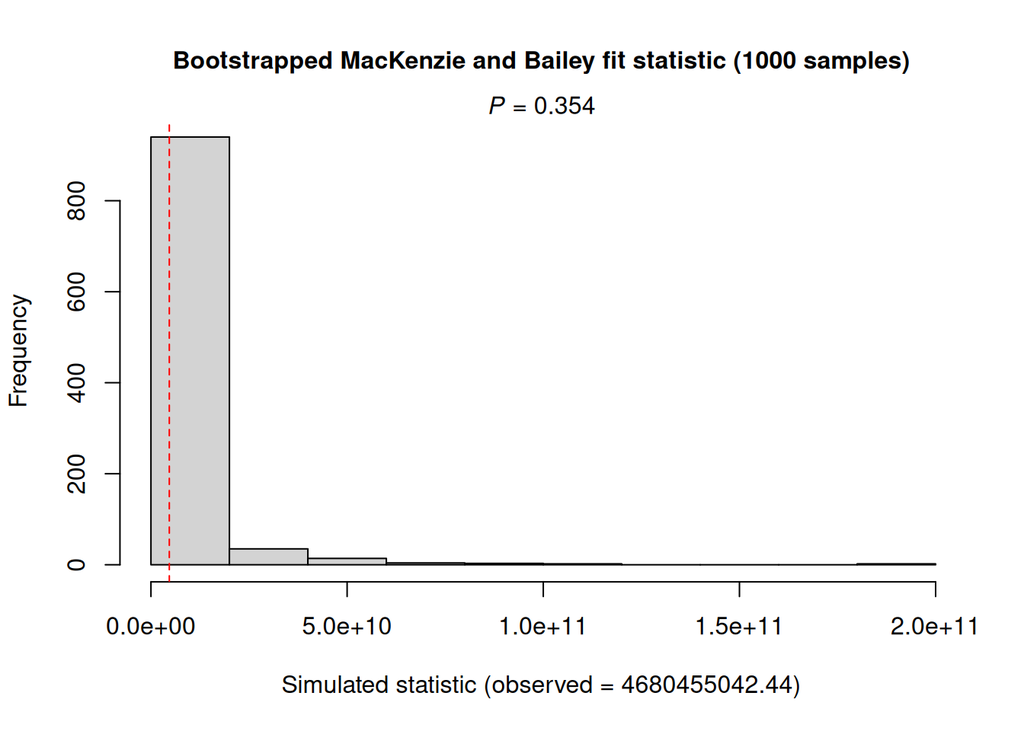

```r
gof_test <- mb.gof.test(modele_ombrelle_odorant, nsim = 1000, plot.hist = TRUE)
```

```r
gof_test
```

```
##
## MacKenzie and Bailey goodness-of-fit for single-season occupancy model
##
## Pearson chi-square table:
##
##                                    Cohort Observed Expected   Chi-square
## 0000000000000000000000000000000000      0        2     1.15 6.400000e-01
## 0000000000000000000000000010000000      0        1     0.01 1.310700e+02
## 0000000000001000000000000000000000      0        1     0.03 3.463000e+01
## 0000000000010000100010000000000000      0        1     0.00 5.974500e+02
## 0000000010000100000000010000000000      0        1     0.00 2.488520e+03
## 0000001000000111111110000000100000      0        1     0.00 1.672896e+07
## 0000010000100000000000000000000000      0        1     0.00 3.476800e+02
## 0000010000100001000001000010000001      0        1     0.00 7.939583e+05
## 0000010001101010111110010010001000      0        1     0.00 1.233210e+09
## 0000010010000000001000010000000000      0        1     0.00 3.664743e+04
## 0000100000000010100000000000000000      0        1     0.00 6.130000e+02
## 0010001111010010110000001010000000      0        1     0.00 3.991055e+08
## 0011010000010010100100000000000001      0        1     0.00 7.921886e+06
## 0100000000000001000100000001000000      0        1     0.00 3.015317e+04
## 0100101100010111100000000.00010000      1        1     0.00 1.397316e+09
## 000000000000000100100000...0000010      2        1     0.00 1.827542e+04
## 000000001100101000....100010101001      3        1     0.00 1.614355e+08
## 0000000000000...110100000100100000      4        1     0.00 1.611195e+06
## 0011010001....11.00100000.00000000      5        1     0.00 1.006058e+06
## 00001100.0000000000000000.00000000      6        1     0.00 5.500090e+03
## 0000.0000000101110100..00100010.11      7        1     0.00 3.488012e+07
## 000.111011010110100100000000000000      8        1     0.00 1.370928e+09
## 000.0100.0100100011100000010000000      9        1     0.00 5.542256e+07
##
## Chi-square statistic = 4680455042
## Number of bootstrap samples = 1000
## P-value = 0.354
##
## Quantiles of bootstrapped statistics:
##      0%     25%     50%     75%    100%
## 5.4e+07 1.2e+09 2.9e+09 6.5e+09 2.0e+11
##
## Estimate of c-hat = 0.7
```

On a un c-hat<1, il n’y a donc pas de sur-dispersion du modèle.

### Prise en compte de typelieu

#### Génération de modèle et sélection par AICc

Création d’un modèle ombrelle sans odorant :

```r
modele_ombrelle_typelieu <- occu(formula = ~ ecart_attractif + PE + support + typelieu + hauteur_camera_cm ~ 1 , data = data)
summary(modele_ombrelle_typelieu)
```

```
##
## Call:
## occu(formula = ~ecart_attractif + PE + support + typelieu + hauteur_camera_cm ~
##     1, data = data)
##
## Occupancy (logit-scale):
##  Estimate    SE    z P(>|z|)
##      2.65 0.957 2.77 0.00555
##
## Detection (logit-scale):
##                   Estimate      SE      z P(>|z|)
## (Intercept)       -1.39727 0.42675 -3.274 0.00106
## ecart_attractif    0.08243 0.02164  3.809 0.00014
## PE2                0.35496 0.23795  1.492 0.13576
## PE3               -0.46488 0.26842 -1.732 0.08328
## supportPiquet      0.21899 0.29722  0.737 0.46125
## supportRocher      0.33414 0.33326  1.003 0.31604
## typelieuN         -1.19343 0.36342 -3.284 0.00102
## typelieuP         -1.00140 0.31300 -3.199 0.00138
## hauteur_camera_cm -0.00269 0.00623 -0.432 0.66547
##
## AIC: 660.333
## Number of sites: 24
```

```r
options(na.action = "na.fail")
modeles_AICc_typelieu = dredge(modele_ombrelle_typelieu)
```

```
## Fixed terms are "psi(Int)" and "p(Int)"
```

```
## Warning in sqrt(diag(vcv)): Production de NaN
```

```r
head(modeles_AICc_typelieu)
```

```
## Global model call: occu(formula = ~ecart_attractif + PE + support + typelieu + hauteur_camera_cm ~
##     1, data = data)
## ---
## Model selection table
##    psi(Int) p(Int) p(ecr_att) p(htr_cmr_cm) p(PE) p(spp) p(typ) df   logLik
## 22    2.527 -1.401    0.08243                   +             +  7 -320.797
## 20    2.528 -1.559    0.09749     1.167e-04                   +  6 -324.880
## 18   11.920 -1.545    0.09636                                 +  5 -326.911
## 24    2.527 -1.398    0.08239    -4.032e-05     +             +  8 -320.797
## 26    2.603 -1.696    0.09749                          +      +  7 -324.279
## 30    2.593 -1.537    0.08243                   +      +      +  9 -320.255
##     AICc delta weight
## 22 662.6  0.00  0.728
## 20 666.7  4.11  0.093
## 18 667.2  4.56  0.074
## 24 667.2  4.60  0.073
## 26 669.6  6.97  0.022
## 30 671.4  8.77  0.009
## Models ranked by AICc(x)
```

Il y a un message d’avertissement : “Warning in sqrt(diag(vcv)) : Production de NaN” En effet, le modèle numéro 18 a un problème :

```r
# Repérer les modèles avec SE manquantes
which(is.na(modeles_AICc_typelieu$SE))  # si SE est une colonne du tableau
```

```
## integer(0)
```

```r
# Sinon, il faut regarder les modèles ajustés individuellement
liste_modeles <- get.models(modeles_AICc_typelieu, subset = TRUE)

# Vérifier la convergence de chacun
sapply(liste_modeles, function(m) m@opt$convergence)  # 0 = OK, autre = problème
```

```
## 22 20 18 24 26 30 21 28 10 14 23 32 12 16  4  8 29  6  2 17 19 31 13 25 15 27
##  0  0  0  0  0  0  0  0  0  0  0  0  0  0  0  0  0  0  0  0  0  0  0  0  0  0
##  7  9  5 11  3  1
##  0  0  0  0  0  0
```

```r
# Vérifier les SE de chacun
sapply(liste_modeles, function(m) any(is.na(SE(m)) | SE(m) > 10))  # seuil arbitraire à ajuster
```

```
##    22    20    18    24    26    30    21    28    10    14    23    32    12
## FALSE FALSE  TRUE FALSE FALSE FALSE FALSE FALSE FALSE FALSE FALSE FALSE FALSE
##    16     4     8    29     6     2    17    19    31    13    25    15    27
## FALSE FALSE FALSE FALSE FALSE FALSE FALSE FALSE FALSE FALSE FALSE FALSE FALSE
##     7     9     5    11     3     1
## FALSE FALSE FALSE FALSE FALSE FALSE
```

```r
formula(liste_modeles[["18"]])
```

```
## ~ecart_attractif + typelieu + 1 ~ 1
```

```r
summary(liste_modeles[["18"]])
```

```
##
## Call:
## occu(formula = ~ecart_attractif + typelieu + 1 ~ 1, data = data)
```

```
## Warning in sqrt(diag(vcov(obj, fixedOnly = fixedOnly))): Production de NaN
```

```
## Occupancy (logit-scale):
##  Estimate  SE   z P(>|z|)
##      11.9 NaN NaN     NaN
##
## Detection (logit-scale):
##                 Estimate     SE     z  P(>|z|)
## (Intercept)      -1.5448 0.1979 -7.81 5.92e-15
## ecart_attractif   0.0964 0.0208  4.64 3.49e-06
## typelieuN        -1.1907 0.2468 -4.82 1.41e-06
## typelieuP        -1.0760 0.2401 -4.48 7.44e-06
##
## AIC: 663.8211
## Number of sites: 24
```

```
## Warning in sqrt(diag(v)): Production de NaN
```

```
## Warning: Large or missing SE values. Be very cautious using these results.
```

Cependant, ce modèle a une AICc supérieure de 2 au meilleur modèle. Cela fait qu’il ne sera pas pris en compte dans nos conclusions car on ne fera pas de modèle averaging. Ce message d’avertissement n’a donc pas d’impact sur la suite de notre étude. Le meilleur modèle est donc le modèle 22 On vérifie qu’il n’y a pas de problème avec celui-là non plus avant de continuer :

```r
summary(liste_modeles[["22"]])
```

```
##
## Call:
## occu(formula = ~ecart_attractif + PE + typelieu + 1 ~ 1, data = data)
##
## Occupancy (logit-scale):
##  Estimate    SE    z P(>|z|)
##      2.53 0.836 3.02  0.0025
##
## Detection (logit-scale):
##                 Estimate     SE     z  P(>|z|)
## (Intercept)      -1.4010 0.2431 -5.76 8.26e-09
## ecart_attractif   0.0824 0.0216  3.81 1.38e-04
## PE2               0.3598 0.2378  1.51 1.30e-01
## PE3              -0.4651 0.2682 -1.73 8.28e-02
## typelieuN        -1.1001 0.2583 -4.26 2.05e-05
## typelieuP        -0.9786 0.2495 -3.92 8.78e-05
##
## AIC: 655.5932
## Number of sites: 24
```

Il n’y a pas de problème avec le meilleur modèle. On peut continuer.

Récupération des meilleurs modèles ayant : $\Delta AICc <2$

```r
modeles_selection_typelieu = get.models(
  modeles_AICc_typelieu,
  subset = delta < 2)

length(modeles_selection_typelieu) #nombre de modeles retenus
```

```
## [1] 1
```

Il n’y a qu’un seul meilleur modèle, et on ne fait pas de modèle average.

```r
meilleur_modele_typelieu = modeles_selection_typelieu[[1]]
summary(meilleur_modele_typelieu)
```

```
##
## Call:
## occu(formula = ~ecart_attractif + PE + typelieu + 1 ~ 1, data = data)
##
## Occupancy (logit-scale):
##  Estimate    SE    z P(>|z|)
##      2.53 0.836 3.02  0.0025
##
## Detection (logit-scale):
##                 Estimate     SE     z  P(>|z|)
## (Intercept)      -1.4010 0.2431 -5.76 8.26e-09
## ecart_attractif   0.0824 0.0216  3.81 1.38e-04
## PE2               0.3598 0.2378  1.51 1.30e-01
## PE3              -0.4651 0.2682 -1.73 8.28e-02
## typelieuN        -1.1001 0.2583 -4.26 2.05e-05
## typelieuP        -0.9786 0.2495 -3.92 8.78e-05
##
## AIC: 655.5932
## Number of sites: 24
```

Le modèle ayant la plus faible AIC inclue les paramètres : ecart_attractif, typelieu et PE.

#### Test de la sur-dispersion du modèle

On teste s’il y a une sur-dispersion, pour pouvoir adapter le modèle en conséquences.

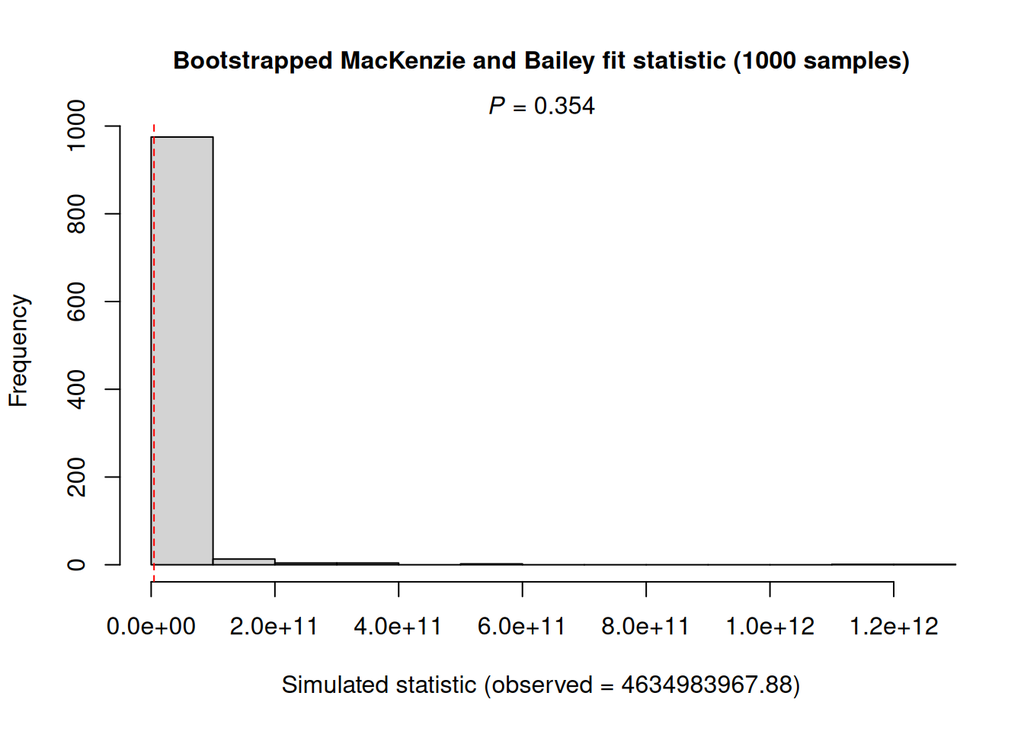

```r
gof_test <- mb.gof.test(meilleur_modele_typelieu, nsim = 1000, plot.hist = TRUE)
```

```r
gof_test
```

```
##
## MacKenzie and Bailey goodness-of-fit for single-season occupancy model
##
## Pearson chi-square table:
##
##                                    Cohort Observed Expected   Chi-square
## 0000000000000000000000000000000000      0        2     1.22 5.000000e-01
## 0000000000000000000000000010000000      0        1     0.01 1.424800e+02
## 0000000000001000000000000000000000      0        1     0.03 3.782000e+01
## 0000000000010000100010000000000000      0        1     0.00 6.016700e+02
## 0000000010000100000000010000000000      0        1     0.00 2.525610e+03
## 0000001000000111111110000000100000      0        1     0.00 1.602591e+07
## 0000010000100000000000000000000000      0        1     0.00 3.632700e+02
## 0000010000100001000001000010000001      0        1     0.00 7.598433e+05
## 0000010001101010111110010010001000      0        1     0.00 1.557619e+09
## 0000010010000000001000010000000000      0        1     0.00 3.630520e+04
## 0000100000000010100000000000000000      0        1     0.00 6.200800e+02
## 0010001111010010110000001010000000      0        1     0.00 4.190256e+08
## 0011010000010010100100000000000001      0        1     0.00 7.280484e+06
## 0100000000000001000100000001000000      0        1     0.00 2.972463e+04
## 0100101100010111100000000.00010000      1        1     0.00 1.461134e+09
## 000000000000000100100000...0000010      2        1     0.00 2.049875e+04
## 000000001100101000....100010101001      3        1     0.00 1.480612e+08
## 0000000000000...110100000100100000      4        1     0.00 1.735614e+06
## 0011010001....11.00100000.00000000      5        1     0.00 1.017351e+06
## 00001100.0000000000000000.00000000      6        1     0.00 6.311230e+03
## 0000.0000000101110100..00100010.11      7        1     0.00 2.905472e+07
## 000.111011010110100100000000000000      8        1     0.00 9.471324e+08
## 000.0100.0100100011100000010000000      9        1     0.00 4.604076e+07
##
## Chi-square statistic = 4634983968
## Number of bootstrap samples = 1000
## P-value = 0.354
##
## Quantiles of bootstrapped statistics:
##      0%     25%     50%     75%    100%
## 2.1e+07 1.1e+09 2.7e+09 6.8e+09 1.3e+12
##
## Estimate of c-hat = 0.34
```

On a un c-hat<1, il n’y a donc pas de sur-dispersion du modèle.

## Calcul du coefficient de détermination marginal

```r
# Modèle avec covariables
mod_final_odorant <- occu(formula = ~ ecart_attractif + PE + odorant ~ 1 , data = data)

mod_final_typelieu <- occu(formula = ~ ecart_attractif + PE + typelieu ~ 1 , data = data)

# Pseudo-R² de McFadden pour le modèle odorant
R2_McFadden_odorant <- 1 - (logLik(mod_final_odorant)/logLik(modele_naif))
R2_McFadden_odorant
```

```
## 'log Lik.' 0.0799861 (df=8)
```

```r
# Pseudo-R² de McFadden pour le modèle typelieu
R2_McFadden_typelieu <- 1 - (logLik(mod_final_typelieu)/logLik(modele_naif))
R2_McFadden_typelieu
```

```
## 'log Lik.' 0.08022597 (df=7)
```

```r
check_singularity(moy_modeles_odorant)
```

```
## [1] FALSE
```

```r
check_singularity(meilleur_modele_typelieu)
```

```
## [1] FALSE
```

Il n’y a pas de singularité. 8,0% de notre variance est expliquée par les paramètres du modèle (dans le cas avec odorant). Il en est de même dans le cas avec typelieu. Ces coefficients de détermination marginaux sont très faibles. Cela pourrait être expliqué par le fait que l’occupancy est mise en constante et qu’on n’ajuste pas cette partie du modèle avec des covariables d’habitat par exemple.

## Représentation graphique des résultats

### Effet de l’ecart_attractif

Représentation de l’effet de l’écart attractif (à partir du modèle prenant en compte typelieu) :

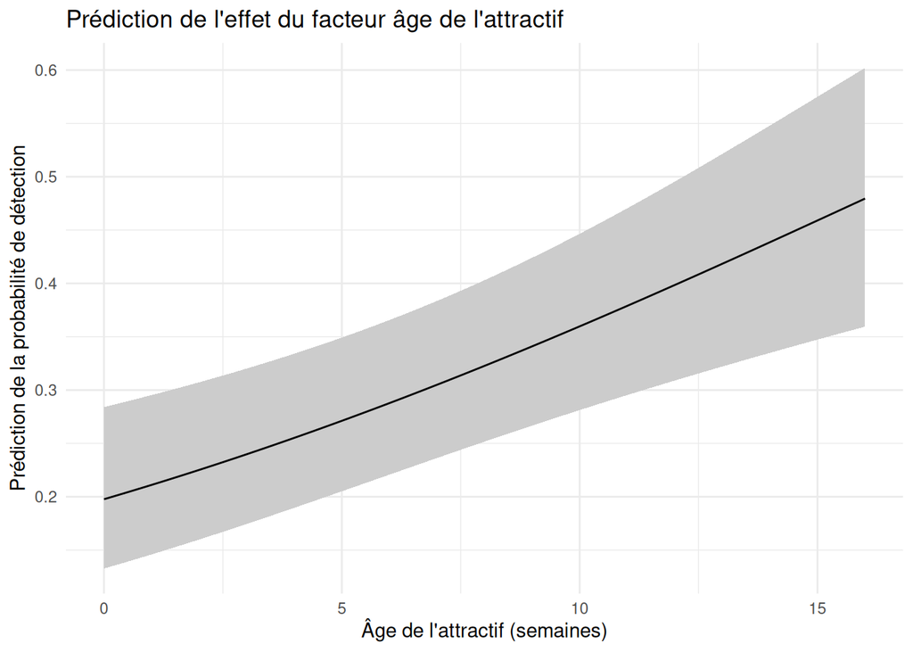

```r
effet_ecart_attractif <- plotEffectsData(mod_final_typelieu, type = "det", covariate = "ecart_attractif")

ggplot(effet_ecart_attractif, aes(x = covariateValue, y = Predicted)) +
  geom_ribbon(aes(ymin = lower, ymax = upper), fill = "grey80") +
  geom_line() +
  labs(title = "Prédiction de l'effet du facteur âge de l'attractif", x = "Âge de l'attractif (semaines)", y = "Prédiction de la probabilité de détection") +
  theme_minimal()
```

```r
ggsave(filename = "Plots/Site_Occupancy/Site_Occupancy_ecart_attractif.jpg")
```

Représentation de l’effet de l’écart attractif (à partir du modèle prenant en compte odorant) :

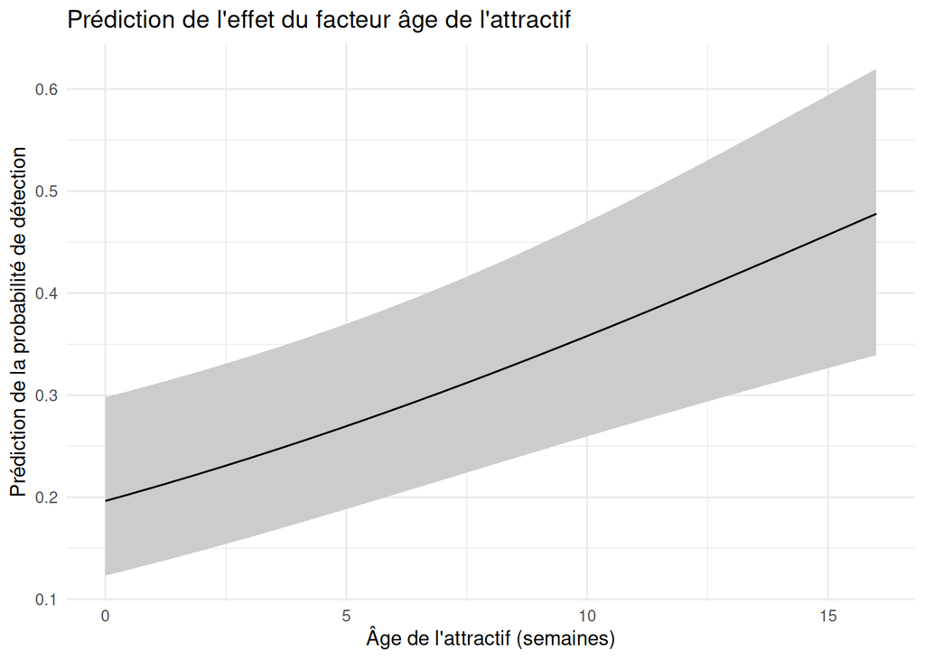

```r
effet_ecart_attractif2 <- plotEffectsData(mod_final_odorant, type = "det", covariate = "ecart_attractif")

ggplot(effet_ecart_attractif2, aes(x = covariateValue, y = Predicted)) +
  geom_ribbon(aes(ymin = lower, ymax = upper), fill = "grey80") +
  geom_line() +
  labs(title = "Prédiction de l'effet du facteur âge de l'attractif", x = "Âge de l'attractif (semaines)", y = "Prédiction de la probabilité de détection") +
  theme_minimal()
```

```r
ggsave(filename = "Plots/Site_Occupancy/Site_Occupancy_ecart_attractif2.jpg")
```

### Effet de PE

Représentation de l’effet de PE (à partir du modèle prenant en compte typelieu) :

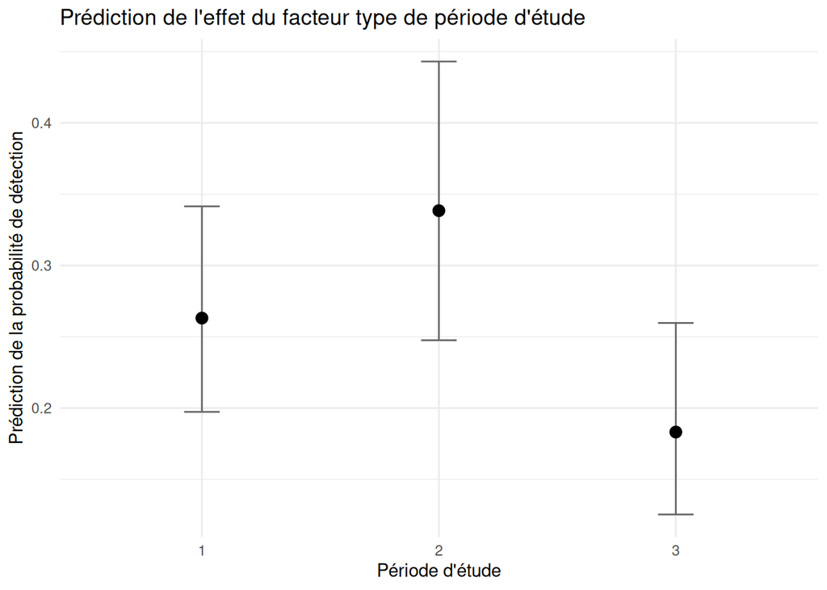

```r
effet_PE <- plotEffectsData(mod_final_typelieu, type = "det", covariate = "PE")

ggplot(effet_PE, aes(x = covariateValue, y = Predicted)) +
  geom_errorbar(aes(ymin = lower, ymax = upper), width = 0.15, color = "grey40") +
  geom_point(size = 3, color = "black") +
  labs(title = "Prédiction de l'effet du facteur type de période d'étude", x = "Période d'étude", y = "Prédiction de la probabilité de détection") +
  theme_minimal()
```

```r
ggsave(filename = "Plots/Site_Occupancy/Site_Occupancy_PE.jpg")
```

Représentation de l’effet de PE (à partir du modèle prenant en compte odorant) :

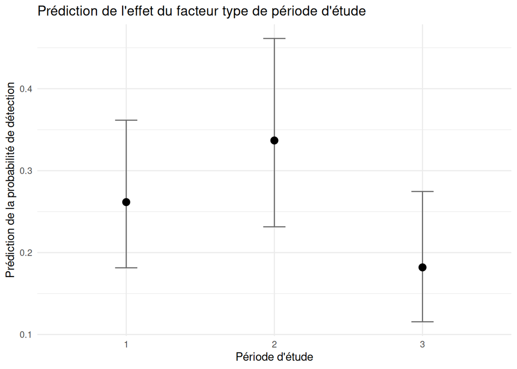

```r
effet_PE2 <- plotEffectsData(mod_final_odorant, type = "det", covariate = "PE")

ggplot(effet_PE2, aes(x = covariateValue, y = Predicted)) +
  geom_errorbar(aes(ymin = lower, ymax = upper), width = 0.15, color = "grey40") +
  geom_point(size = 3, color = "black") +
  labs(title = "Prédiction de l'effet du facteur type de période d'étude", x = "Période d'étude", y = "Prédiction de la probabilité de détection") +
  theme_minimal()
```

```r
ggsave(filename = "Plots/Site_Occupancy/Site_Occupancy_PE2.jpg")
```

### Effet de typelieu

Représentation de l’effet de typelieu :

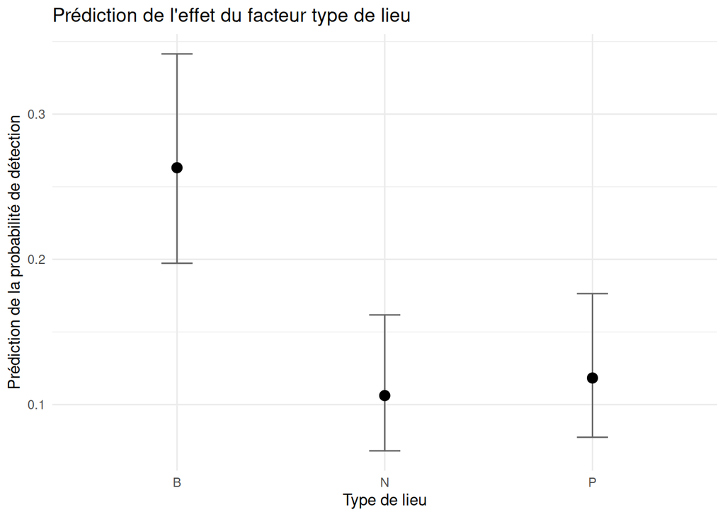

```r
effet_typelieu <- plotEffectsData(mod_final_typelieu, type = "det", covariate = "typelieu")

ggplot(effet_typelieu, aes(x = covariateValue, y = Predicted)) +
  geom_errorbar(aes(ymin = lower, ymax = upper), width = 0.15, color = "grey40") +
  geom_point(size = 3, color = "black") +
  labs(title = "Prédiction de l'effet du facteur type de lieu", x = "Type de lieu", y = "Prédiction de la probabilité de détection") +
  theme_minimal()
```

```r
ggsave(filename = "Plots/Site_Occupancy/Site_Occupancy_typelieu.jpg")
```

### Effet de l’odorant

Représentation de l’effet de l’odorant :

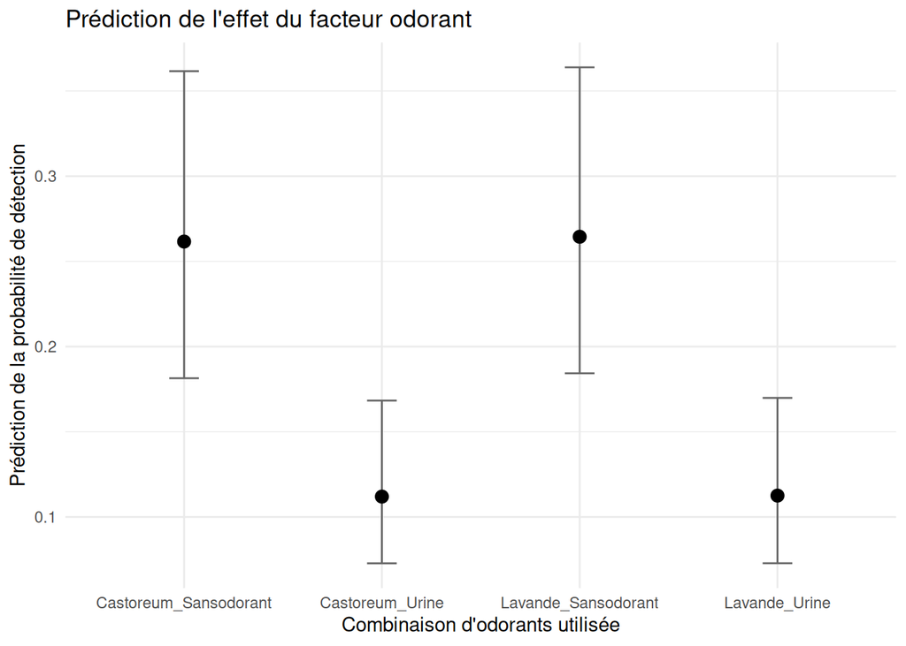

```r
effet_odorant <- plotEffectsData(mod_final_odorant, type = "det", covariate = "odorant")

ggplot(effet_odorant, aes(x = covariateValue, y = Predicted)) +
  geom_errorbar(aes(ymin = lower, ymax = upper), width = 0.15, color = "grey40") +
  geom_point(size = 3, color = "black") +
  labs(title = "Prédiction de l'effet du facteur odorant", x = "Combinaison d'odorants utilisée", y = "Prédiction de la probabilité de détection") +
  theme_minimal()
```

```r
ggsave(filename = "Plots/Site_Occupancy/Site_Occupancy_Odorant.jpg")
```